# TCAC 2.0 — Vectorisation Report

SPECTER2 embeddings, keypaper-similarity scoring

Author

Rainer M. Krug

Published

July 2, 2026

```r
library(targets)
library(htmltools)
library(knitr)
```

# Embeddings Overview

The corpus contains the following missing titles and abstracts

```r
ds <- arrow::open_dataset(tar_read(corpus_tcac20))
n_total <- nrow(ds)
n_na <- ds |> dplyr::filter(is.na(title)) |> nrow()
n_empty <- ds |> dplyr::filter(!is.na(title), title == "") |> nrow()
n_present <- n_total - n_na - n_empty

tibble::tibble(
  state = c("title present", "title empty (nchar=0)", "title NA", "total"),
  n = c(n_present, n_empty, n_na, n_total)
) |>
  dplyr::mutate(`%` = 100 * n / n_total) |>
  knitr::kable(
    digits = 3,
    format.args = list(big.mark = ",", nsmall = 3),
    align = c("l", "r", "r"),
    caption = "Title presence in the OpenAlex corpus extract. Works in NA or empty rows are dropped from the title-variant embedding by preprocessor_title()."
  )
```

Table 1: Title presence in the OpenAlex corpus extract. Works in NA or empty rows are dropped from the title-variant embedding by preprocessor_title().

| state | n | % |
| --- | --- | --- |
| title present | 5,768,156.000 | 99.947 |
| title empty (nchar=0) | 2,583.000 | 0.045 |
| title NA | 470.000 | 0.008 |
| total | 5,771,209.000 | 100.000 |

```r
ds <- arrow::open_dataset(tar_read(corpus_tcac20))
n_total <- nrow(ds)
n_na <- ds |> dplyr::filter(is.na(abstract)) |> nrow()
n_empty <- ds |> dplyr::filter(!is.na(abstract), abstract == "") |> nrow()
n_present <- n_total - n_na - n_empty

tibble::tibble(
  state = c(
    "abstract present",
    "abstract empty (nchar=0)",
    "abstract NA",
    "total"
  ),
  n = c(n_present, n_empty, n_na, n_total)
) |>
  dplyr::mutate(`%` = 100 * n / n_total) |>
  knitr::kable(
    digits = 3,
    format.args = list(big.mark = ",", nsmall = 3),
    align = c("l", "r", "r"),
    caption = "Abstract presence in the OpenAlex corpus extract. Works without abstracts are dropped from the abstract and title_abstract variants."
  )
```

Table 2: Abstract presence in the OpenAlex corpus extract. Works without abstracts are dropped from the abstract and title_abstract variants.

| state | n | % |
| --- | --- | --- |
| abstract present | 4,605,826.000 | 79.807 |
| abstract empty (nchar=0) | 308.000 | 0.005 |
| abstract NA | 1,165,075.000 | 20.188 |
| total | 5,771,209.000 | 100.000 |

The following number of embeddings were determined.

```r
# Embeddings root holds multiple config=<name>/ partitions

emb_meta <- dirname(dirname(dirname(tar_read(emb_tcac20_title)))) |>
  arrow::open_dataset() |>
  dplyr::count(config, source, variant) |>
  dplyr::collect() |>
  tidyr::pivot_wider(names_from = variant, values_from = n, values_fill = 0L) |>
  dplyr::relocate(
    dplyr::any_of(c("title", "abstract", "title_abstract")),
    .after = source
  ) |>
  dplyr::arrange(config, source)


# Total works available per source (before embedding)
n_corpus <- nrow(arrow::open_dataset(tar_read(corpus_tcac20)))
n_keypaper <- nrow(arrow::open_dataset(tar_read(key_works)))

emb_meta <- emb_meta |>
  dplyr::mutate(
    corpus_size = dplyr::if_else(source == "corpus", n_corpus, n_keypaper)
  ) |>
  dplyr::arrange(config, source) |>
  dplyr::mutate(
    corpus_size = dplyr::if_else(source == "corpus", n_corpus, n_keypaper)
  ) |>
  dplyr::relocate(corpus_size, .after = source)

# Map config name → model_id for the caption
cfg <- yaml::read_yaml("input/config.yaml")
active_cfg <- cfg$embeddings$active
model_ids <- vapply(
  cfg$embeddings$configs,
  function(c) c$model %||% NA_character_,
  character(1)
)

knitr::kable(
  emb_meta,
  format.args = list(big.mark = ","),
  caption = sprintf(
    "Embedded works per config × source × variant. Active config: %s (model_id = %s).",
    active_cfg,
    model_ids[[active_cfg]]
  )
)
```

Embedded works per config × source × variant. Active config: SPECTER2_runpod (model_id = allenai/specter2_proximity_merged).

| config | source | corpus_size | title | abstract | title_abstract |
| --- | --- | --- | --- | --- | --- |
| SPECTER2_runpod | corpus | 5,771,209 | 5,768,152 | 4,605,817 | 4,603,392 |
| SPECTER2_runpod | keypaper | 44 | 44 | 44 | 44 |

## Language distribution

SPECTER2 is a primarily English model; non-English works can still embed but their similarity scores are less reliable. Useful gut-check on how much of the corpus the embedding is well-suited for.

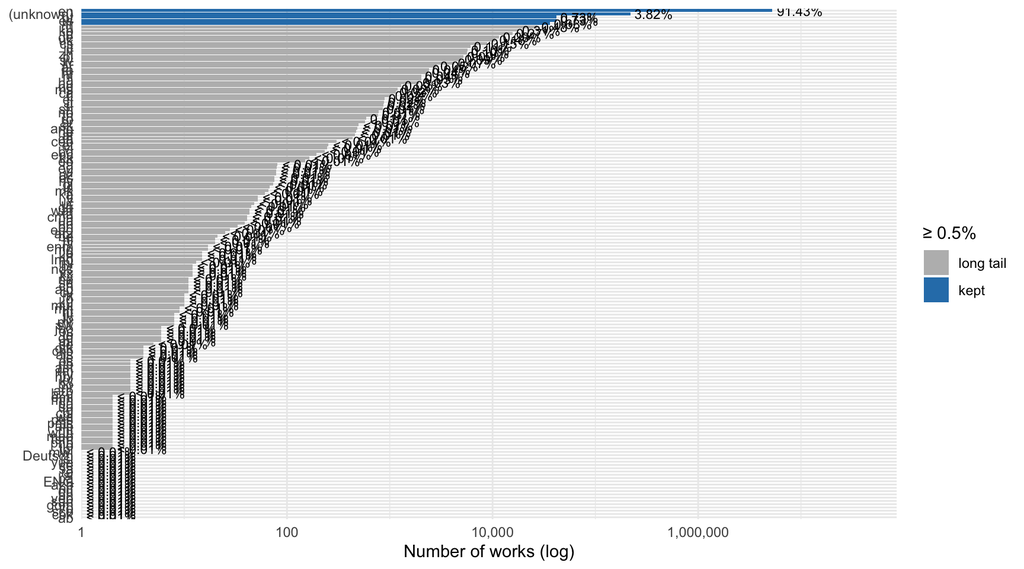

Figure 1: Works per OpenAlex `language`, log x-axis. Blue bars = ≥ 0.5% of the corpus; grey = long tail. SPECTER2 was trained primarily on English; treat similarity scores for low-resource languages with caution.

```r
tar_read(viz_language_fig)
```

## Input text length per variant

How long is the text actually sent to TEI? `title_abstract` is capped on the title side at `title_cap_combined` chars (config), then joined with the abstract via `[SEP]`. Works far above ~2000 chars may hit the model’s 512-token context window and get silently truncated server-side.

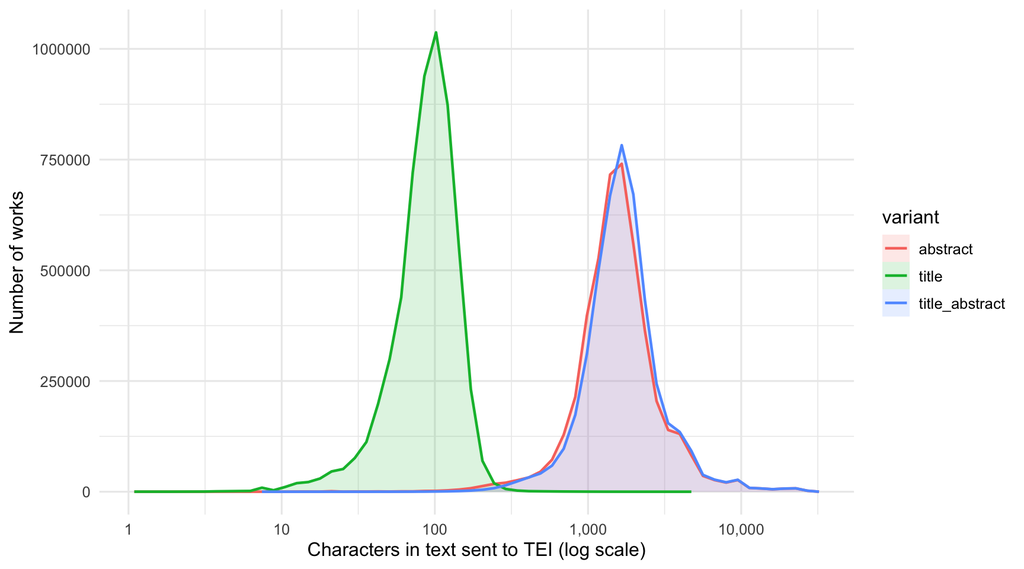

Figure 2: Distribution of input text length per variant (characters, log scale). Title is by definition short; abstract dominates the right tail; title_abstract is title (capped) + sep + abstract.

```r
tar_read(viz_text_length_fig)
```

### Silent truncation by TEI

SPECTER2 truncates input above ~512 tokens (~2,000 characters) **without warning**. Embeddings for truncated works are based only on the first 2k characters of text — methodologically worth surfacing.

```r
tar_read(viz_truncation_stats) |>
  knitr::kable(
    format.args = list(big.mark = ","),
    caption = "Number of works exceeding length thresholds per variant. The `> 2048` column approximates how many were silently truncated by TEI."
  )
```

Table 3: Number of works exceeding length thresholds per variant. The `> 2048` column approximates how many were silently truncated by TEI.

| variant | n | > 1024 | > 2048 | > 4096 | % > 2048 |
| --- | --- | --- | --- | --- | --- |
| title | 5,770,739 | 484 | 121 | 31 | 0.002 |
| abstract | 4,606,134 | 3,736,541 | 1,207,680 | 271,116 | 26.219 |
| title_abstract | 4,606,134 | 3,938,368 | 1,378,313 | 292,814 | 29.923 |

# Score distributions per variant

For each corpus work, the **max** cosine similarity against any keypaper is the single most useful summary — it answers “how close is this work to its nearest reference paper?” A well-calibrated embedding produces a bimodal distribution: relevant works pile up on the right, irrelevant on the left.

```r
tar_read(viz_score_summary_tbl) |>
  knitr::kable(
    caption = "Summary statistics of the embeddings, split by source of embedding.",
    format.args = list(big.mark = ","),
  )
```

Table 4: Summary statistics of the embeddings, split by source of embedding.

| variant | n | min | mean | max | p10 | p50 | p90 | p99 |
| --- | --- | --- | --- | --- | --- | --- | --- | --- |
| title | 5,768,152 | 0.7594575 | 0.8781095 | 0.9999999 | 0.8417623 | 0.8764124 | 0.9166403 | 0.9542301 |
| abstract | 4,605,817 | 0.5120143 | 0.8721625 | 1.0000000 | 0.8301897 | 0.8729885 | 0.9130774 | 0.9382628 |
| title_abstract | 4,603,392 | 0.7292237 | 0.8708731 | 1.0000000 | 0.8303197 | 0.8711098 | 0.9110600 | 0.9391784 |

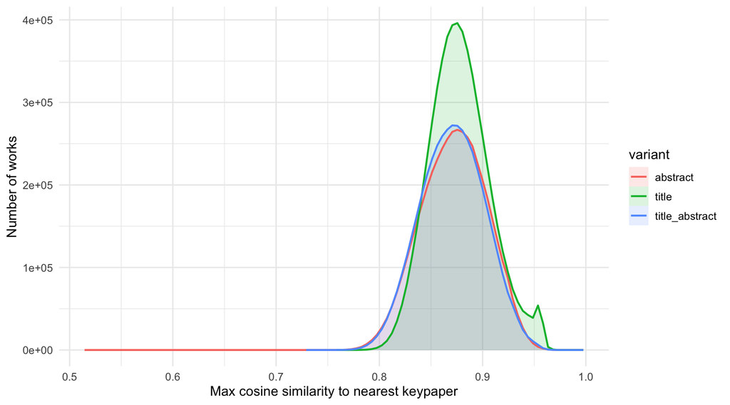

Figure 3: Distribution of max cosine similarity to keypapers, per variant. Higher = closer to nearest reference. A clear bimodal shape indicates the embedding separates topic-relevant from off-topic works.

```r
tar_read(viz_score_dist_fig)
```

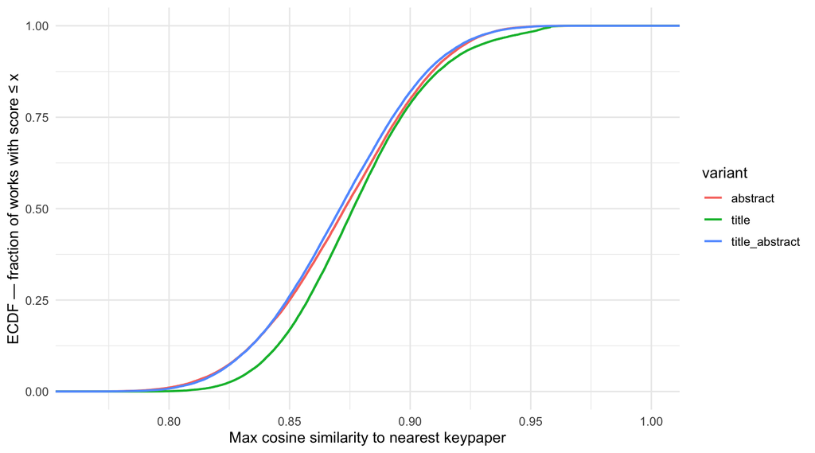

Figure 4: Empirical CDF of max cosine similarity to nearest keypaper, per variant (subsample of 50,000 works per variant, seed = 13). Read horizontally: for any score threshold, the curves give the fraction of works at or below that score. The gap between curves shows where variants disagree about how ‘close to relevant’ a typical work is.

```r
tar_read(viz_score_ecdf_fig)
```

## Score vs publication year

Does similarity to keypapers correlate with how recent a work is? A strong bias either way suggests the keypaper set is anchored to a particular era and may need broadening.

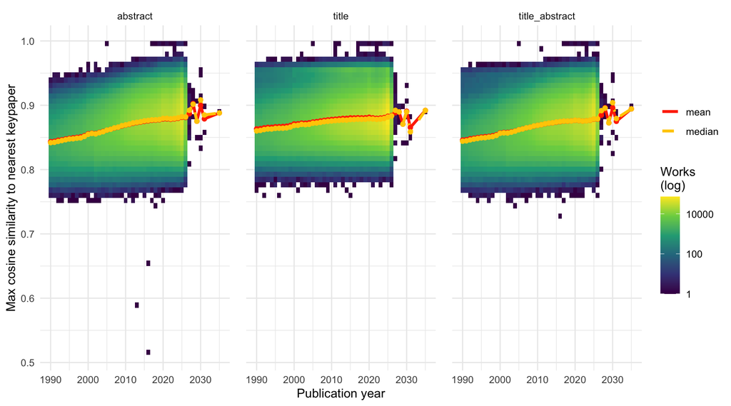

```r
tar_read(viz_score_year_fig)
```

## Score vs citation count

Are high-similarity works also highly cited? Topical relevance and citation impact are different signals — a strong correlation here would suggest the embedding is mostly picking up “prestige”, not topic.

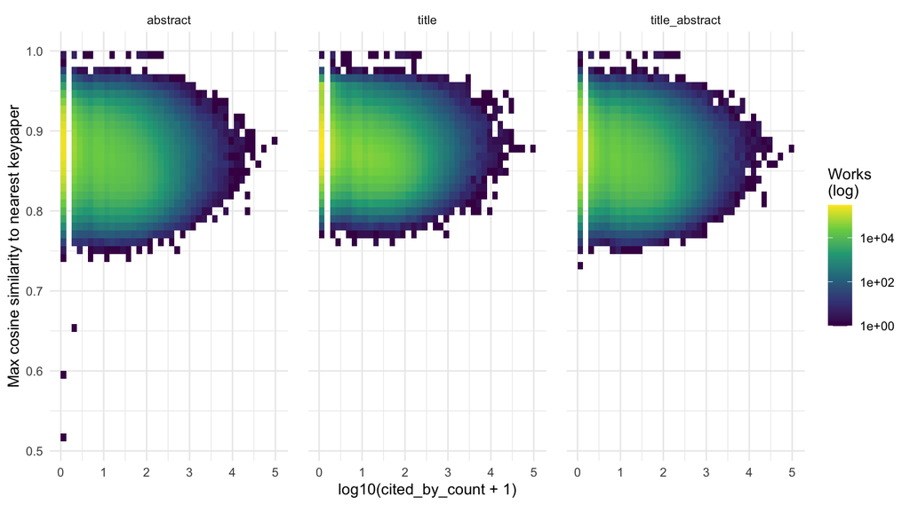

Figure 6: 2D histogram of max cosine similarity (y) against log10(cited_by_count + 1) (x), per variant. A horizontal band = no relationship between citation and similarity (good — they’re independent signals). Diagonal correlation would suggest the embedding co-varies with citation impact rather than topic.

```r
tar_read(viz_citation_score_fig)
```

# Work-type breakdown

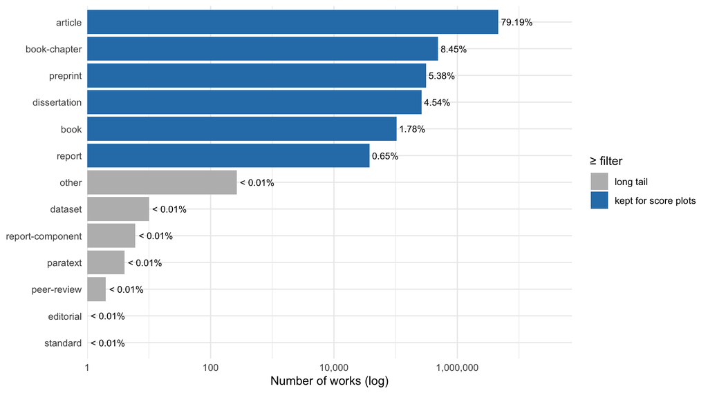

Figure 7: Number of works per OpenAlex `type`, log x-axis. Blue bars = types representing ≥ 0.5% of the corpus (kept for the score plots below); grey = long-tail types (still shown here for context).

```r
tar_read(viz_type_count_fig)
```

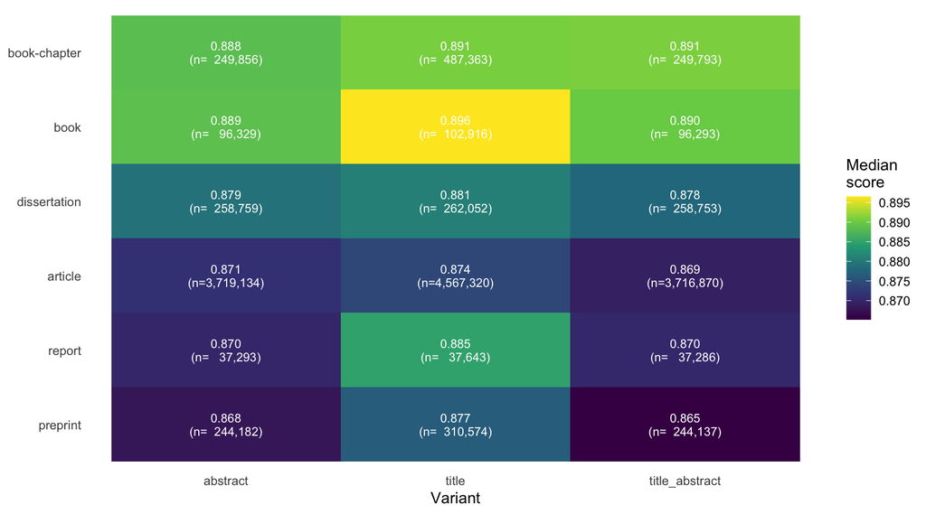

Figure 8: Median max-similarity score per (type, variant), for types with ≥ 0.5% of the corpus. Cells annotated with `median (n=…)`. Types sorted by overall median — top of the column scores best.

```r
tar_read(viz_type_score_heatmap_fig)
```

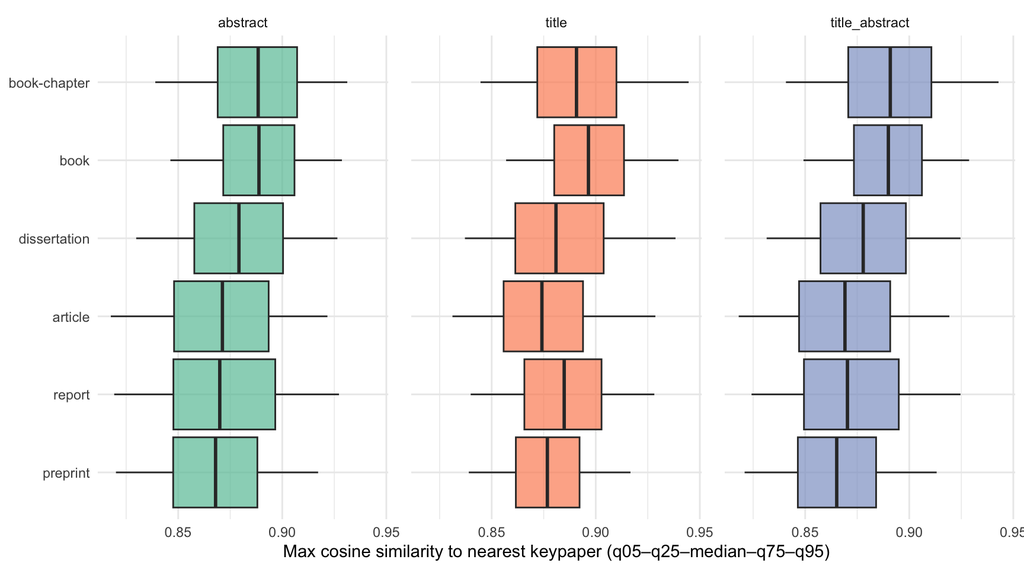

Figure 9: Score distribution per type, per variant. Boxes show q05–q25–median–q75–q95 (precomputed). Filtered to types with ≥ 0.5% of the corpus. Variant facets share the y-axis; spread within a type indicates how heterogeneous its content is.

```r
tar_read(viz_type_score_box_fig)
```

# Top / bottom matches per variant

Sanity check: do the highest-scoring works read as on-topic, and the lowest as off-topic? If not, either the embedding model isn’t capturing the topic, the keypaper set is too narrow, or the search-term filter let in noise.

```r
tb <- tar_read(viz_top_bottom)
for (v in names(tb)) {
  cat("##", v, "\n\n")
  print(knitr::kable(tb[[v]]))
  cat("\n\n")
}
```

Table 5

## abstract

| rank | max_sim | title |
| --- | --- | --- |
| top 1 | 1.000 | Imagination and transformations to sustainable and just futures |
| top 2 | 1.000 | Living community cookbook: transdisciplinary collaboration for constructing recipes with biocultural value |
| top 3 | 1.000 | Meaningful transdisciplinary collaborations for sustainability: local, artistic, and scientific knowledge |
| top 4 | 1.000 | 9 Dimensions for evaluating how art and creative practice stimulate societal transformations |
| top 5 | 1.000 | Cocina Colaboratorio: cooking transdisciplinary transformations of local food systems |
| top 6 | 1.000 | Building capacities for transformative change towards sustainability: Imagination in Intergovernmental Science-Policy Scenario Processes |
| top 7 | 1.000 | Co-creating a festival with and for rural commoning initiatives: a transdisciplinary place-based process |
| top 8 | 1.000 | Reimagining Ocean Stewardship: Arts-Based Methods to ‘Hear’ and ‘See’ Indigenous and Local Knowledge in Ocean Management |
| top 9 | 1.000 | Creative arts for sustainability transformations—Exploring children’s theater for the UN Sustainable Development Goals |
| top 10 | 1.000 | Creative, embodied practices, and the potentialities for sustainability transformations |
| bottom 1 | 0.751 | Ductile Fracture Mechanism of Low-Temperature In-48Sn Alloy Joint Under High Strain Rate Loading |
| bottom 2 | 0.750 | Haemodynamic Effects of Combined Nitroglycerin‐ and Dobutamine‐Infusions After Coronary By‐Pass Surgery With One Nitroglycerin‐Related Complication |
| bottom 3 | 0.750 | Dose-Effect Relationships of Prostaglandin E1 in Severe Endstage Chronic Heart Failure. |
| bottom 4 | 0.746 | Actions of bretylium tosylate on the cardiovascular system of the dog |
| bottom 5 | 0.743 | Density and magnetic fluctuations in type III-ELM pedestal evolution in JET: experimental and numerical characterization |
| bottom 6 | 0.741 | EFFECTS OF CLONIDINE ON CANINE CARDIAC NEUROEFFECTOR STRUCTURES CONTROLLING HEART RATE |
| bottom 7 | 0.738 | Electrical Properties and EPR Studies of Mn-Doped Snl-xPbxTe Crystls (1) |
| bottom 8 | 0.656 | Annual Meetings of the Michigan Academy, Saginaw Valley State University, March 4, 2016 |
| bottom 9 | 0.591 | Abstracts - 2011 Meetings |
| bottom 10 | 0.512 | Annual Meetings of the Michigan Academy, Andrews University, March 13, 2015 |

## title

| rank | max_sim | title |
| --- | --- | --- |
| top 1 | 1.000 | Reimagining Ocean Stewardship: Arts-Based Methods to ‘Hear’ and ‘See’ Indigenous and Local Knowledge in Ocean Management |
| top 2 | 1.000 | Envisioning desirable futures in small-scale fisheries: a transdisciplinary arts-based co-creation process |
| top 3 | 1.000 | Common ground |
| top 4 | 1.000 | Living community cookbook: transdisciplinary collaboration for constructing recipes with biocultural value |
| top 5 | 1.000 | Common Ground |
| top 6 | 1.000 | Restoring our senses, restoring the Earth. Fostering imaginative capacities through the arts for envisioning climate transformations |
| top 7 | 1.000 | Meaningful transdisciplinary collaborations for sustainability: local, artistic, and scientific knowledge |
| top 8 | 1.000 | Creative arts for sustainability transformations—Exploring children’s theater for the UN Sustainable Development Goals |
| top 9 | 1.000 | Creative, embodied practices, and the potentialities for sustainability transformations |
| top 10 | 1.000 | Imagination and transformations to sustainable and just futures |
| bottom 1 | 0.772 | Vibronic Interaction in Molecules and Ions. II. The first order Jahn-Teller interaction and spin-orbit coupling in doubly degenerate electronic states of C<sub>3v</sub>type molecules |
| bottom 2 | 0.771 | Electronic properties of InAs/GaAs self-assembled quantum dots studied by photocurrent spectroscopy |
| bottom 3 | 0.771 | MONOLAYER STUDIES OF 5‐(4‐CARB‐ OXYPHENYL)‐10,15,20‐TRITOLYL‐PORPHYRIN‐II. PHOTOVOLTAIC STUDY OF MULTILAYER SANDWICH CELLS* |
| bottom 4 | 0.770 | Intramolecular Charge Transfer Effects on the Diradical Character and Second Hyperpolarizabilities of Open-Shell Singlet X−π–X (X = Donor/Acceptor) Systems |
| bottom 5 | 0.767 | Characteristics of photoluminescence due to exciton-exciton scattering in GaAs/AlAs multiple quantum wells |
| bottom 6 | 0.763 | Oxido‐reduction of B800–850 and B880 holochromes isolated from three species of photosynthetic bacteria as studied by electron‐paramagnetic resonance and optical spectroscopy |
| bottom 7 | 0.763 | Exciton binding energies in GaAs films on AlxGa1−xAs substrates |
| bottom 8 | 0.763 | The effects of free carriers on the photoluminescence and photoluminescence excitation spectra of InGaAs-InP quantum wells |
| bottom 9 | 0.762 | Photoluminescence of molecular C70 at 1.5 K. On the nature of the lowest excited states |
| bottom 10 | 0.759 | Photo-Induced Intersubband Transitions in Quantum Wells |

## title_abstract

| rank | max_sim | title |
| --- | --- | --- |
| top 1 | 1.000 | Performing Sustainability: The Power of Theatre in Environmental Communication |
| top 2 | 1.000 | Reimagining Ocean Stewardship: Arts-Based Methods to ‘Hear’ and ‘See’ Indigenous and Local Knowledge in Ocean Management |
| top 3 | 1.000 | Living community cookbook: transdisciplinary collaboration for constructing recipes with biocultural value |
| top 4 | 1.000 | Meaningful transdisciplinary collaborations for sustainability: local, artistic, and scientific knowledge |
| top 5 | 1.000 | Restoring our senses, restoring the Earth. Fostering imaginative capacities through the arts for envisioning climate transformations |
| top 6 | 1.000 | “Narrative images” as a learning approach: (transformative) adaptation scenarios for dealing with urban water risks in Hamburg, Germany |
| top 7 | 1.000 | 9 Dimensions for evaluating how art and creative practice stimulate societal transformations |
| top 8 | 1.000 | Envisioning desirable futures in small-scale fisheries: a transdisciplinary arts-based co-creation process |
| top 9 | 1.000 | Audience Participation and Community Transformation: Contemporary Student-Led Theatre for Development Practice in Ghana |
| top 10 | 1.000 | Co-creating a festival with and for rural commoning initiatives: a transdisciplinary place-based process |
| bottom 1 | 0.754 | THE ACTION OF EXTRACTS OF THE POSTERIOR LOBE OF THE PITUITARY BODY ON THE PULMONARY CIRCULATION |
| bottom 2 | 0.754 | Influence of interdot electronic coupling on photoluminescence spectra of self-assembled InAs/GaAs quantum dots |
| bottom 3 | 0.754 | Excitons in strained (Ga,In)Sb/GaSb quantum wells |
| bottom 4 | 0.753 | Tailoring the character of the band-gap in -, - and -oriented silicon nanowires |
| bottom 5 | 0.753 | Carrier transfer between confined and localized states in type II InAs/GaAsSb quantum wells |
| bottom 6 | 0.752 | Resonant hydrogenic impurity states and1s−2p0transitions in coupled double quantum wells |
| bottom 7 | 0.751 | FRACTIONATION OF SERUM WITH RESPECT TO ITS ACTION IN ENHANCING TISSUE RESPIRATION |
| bottom 8 | 0.750 | EFFECTS OF 1‐SAR‐8‐ALA‐ANGIOTENSIN II ON SYSTEMIC AND PULMONARY HAEMODYNAMICS IN HYPERTENSIVE PATIENTS |
| bottom 9 | 0.748 | Electron-impact-induced allowed transitions between triplet states ofH2 |
| bottom 10 | 0.729 | Annual Meetings of the Michigan Academy, Andrews University, March 13, 2015 |

## Top matches per keypaper

Concrete embedding sanity check: for five randomly-chosen keypapers (seed = 13), the five corpus works with the highest cosine similarity under the `title_abstract` variant. The matches should read as topically related to the keypaper.

```r
tm <- tar_read(viz_top_matches_per_kp)
for (kp in unique(tm$keypaper_id)) {
  rows <- tm[tm$keypaper_id == kp, ]
  title <- rows$keypaper_title[[1]]
  cit <- rows$keypaper_citation[[1]]
  cat("**Keypaper:** ", title, "  \n", cit, "\n\n", sep = "")
  print(knitr::kable(
    rows[, c("rank", "match_title", "match_citation", "similarity")],
    digits = 4,
    col.names = c("rank", "match title", "citation", "similarity"),
    align = c("r", "l", "l", "r")
  ))
  cat("\n\n")
}
```

Table 6

**Keypaper:** Algorithmic Justice League  
Algorithmic Justice League

| rank | match title | citation | similarity |
| --- | --- | --- | --- |
| 1 | Justice in the Age of Algorithms | Abhishek Benedict Kumar et al. (2025) | 0.9630 |
| 2 | ETHICAL AND LEGAL IMPLICATIONS OF ARTIFICIAL INTELLIGENCE (AI) IN CRIMINAL JUSTICE SYSTEM | Neeti Pandey & Chetna Sharma (2025) | 0.9611 |
| 3 | Ethical Considerations in Cloud AI: Addressing Bias and Fairness in Algorithmic Systems | Shreya Gupta (2025) | 0.9585 |
| 4 | Investing in AI Interpretability, Control, and Robustness | Maikel Leon (2026) | 0.9574 |
| 5 | A Feminist Perspective on Artificial Intelligence, Including Code and Conscience for Women | Amit Yadav (2025) | 0.9574 |

**Keypaper:** ART FOR CHANGE: Transformative learning and youth empowerment in a changing climate  
ART FOR CHANGE: Transformative learning and youth empowerment in a changing climate

| rank | match title | citation | similarity |
| --- | --- | --- | --- |
| 1 | ART FOR CHANGE: Transformative learning and youth empowerment in a changing climate | Julia Bentz & Karen O’Brien (2019) | 0.9999 |
| 2 | Promoting Young People’s Ecosocial Participation Through Socially Engaged Art and a New Materialist Approach | Aki Lintumäki (2025) | 0.9737 |
| 3 | The complementarity between art appreciation and philosophy for children in the process of climate change education: sensitive and engaged approaches | Sabrina Fortin et al. (2025) | 0.9733 |
| 4 | Nurturing Transformative Capacities | Adriene Jenik (2025) | 0.9733 |
| 5 | Ecological art pedagogy: co-creation for ecological transformation | Nuray Mamur & Tülay Çelik (2023) | 0.9708 |

**Keypaper:** Cocina Colaboratorio: cooking transdisciplinary transformations of local food systems  
Cocina Colaboratorio: cooking transdisciplinary transformations of local food systems

| rank | match title | citation | similarity |
| --- | --- | --- | --- |
| 1 | Cocina Colaboratorio: cooking transdisciplinary transformations of local food systems | Patricia Balvanera et al. (2025) | 1.0000 |
| 2 | Pathways for Food Systems Transformation: Technologies, Business Models, and Narratives | Dueñas Ocampo, Sebastian (2023) | 0.9706 |
| 3 | Feasting on Participatory Methodologies for Regenerative Food Transitions | Markéta Dolejšová et al. (2022) | 0.9692 |
| 4 | Living community cookbook: transdisciplinary collaboration for constructing recipes with biocultural value | Carolina Gutiérrez Sánchez et al. (2024) | 0.9687 |
| 5 | Food futuring in Timor-Leste: Recombinance, responsiveness, and relationality | David Szanto (2022) | 0.9684 |

**Keypaper:** From Sea to Street  
From Sea to Street

| rank | match title | citation | similarity |
| --- | --- | --- | --- |
| 1 | Wet Imaginaries: Organizing Socio-Ecological Just Futures With(in) Öresund | Tracy Trägårdh (2025) | 0.9650 |
| 2 | Vivre dans un territoire fragile et dynamique : l’apport de la médiation environnementale et artistique dans l’appropriation de nouvelles pratiques d’habiter l’espace littoral | Camille Provendier (2024) | 0.9646 |
| 3 | Thalassophilia and marine identity: Drivers of ‘thick’ marine citizenship | Pamela M. Buchan et al. (2024) | 0.9645 |
| 4 | New dialogues with the Ocean as a recreational diver | Olga (2026) | 0.9602 |
| 5 | *I am the Ocean* – arts and sciences to move from ocean literacy to passion for the ocean | Sam Dupont (2017) | 0.9595 |

**Keypaper:** Realising potentials for arts‐based sustainability science  
Realising potentials for arts‐based sustainability science

| rank | match title | citation | similarity |
| --- | --- | --- | --- |
| 1 | Realising potentials for arts-based sustainability science | María Heras et al. (2021) | 0.9996 |
| 2 | Thoughts on future directions: Art and culture in transformations toward greater sustainability | Nancy Duxbury (2019) | 0.9729 |
| 3 | Meaningful transdisciplinary collaborations for sustainability: local, artistic, and scientific knowledge | M. Azahara Mesa-Jurado et al. (2025) | 0.9728 |
| 4 | Bridging worlds: exploring synergies between the arts and biodiversity conservation | Jarić, Ivan et al. (2025) | 0.9712 |
| 5 | Art and the Environment: Creative Approaches to Sustainability | Nabirye Amina Okwir (2025) | 0.9701 |

# Variant agreement

If `title` and `abstract` agree on a work’s relevance, the title is a reliable proxy for the abstract. Off-diagonal works are interesting candidates for manual inspection: either the title misrepresents the paper or the abstract is poor quality.

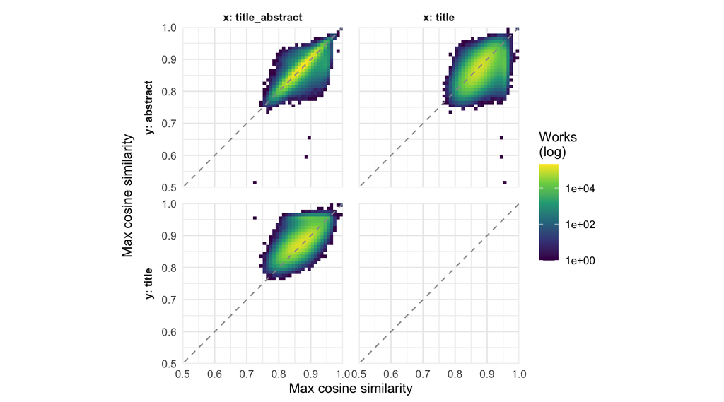

Figure 10: Per-work max similarity to keypapers, plotted pair-wise across the three variants. Each corpus work contributes one point per pair (coloured). The dashed diagonal is perfect agreement; points off it are works the two variants disagree about. Click or box/lasso-select to highlight a work’s points across all pairs.

```r
tar_read(viz_agree_fig)
```

# Keypaper coherence

How tight is the keypaper set itself? Pairwise cosine similarity between the keypapers (title_abstract variant), reordered by average-linkage hierarchical clustering. A coherent set shows clear high-similarity blocks on the diagonal; a scattered set shows a noisier matrix.

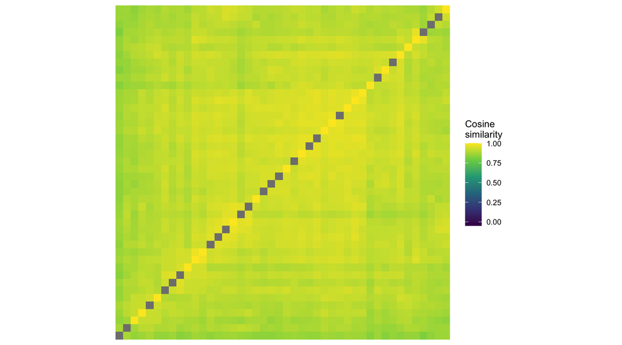

Figure 11: Pairwise cosine similarity between keypapers (title_abstract variant). Axis order is from hierarchical clustering (1 − cosine, average linkage). Block structure on the diagonal indicates topical sub-groups within the keypaper set.

```r
tar_read(viz_keypaper_self_sim_fig)
```

## Per-keypaper score distribution

```r
htmltools::div(
  style = "height: 3200px; overflow: visible;",
  tar_read(viz_keypaper_score_dist_fig)
)
```

[interactive chart not shown]

Figure 12

*Per-keypaper score distribution (q05–q25–median–q75–q95). Keypapers at the top score high across the corpus (broad/generic concepts); keypapers at the bottom are orphans (their topic isn’t well-represented in the corpus). Inputs to keypaper-set curation.*

# Sanity check: embedding L2 norms

SPECTER2 should return roughly normalised vectors (norm ≈ 1). A tight peak near 1 means the model behaved as expected; outliers or zero-norm vectors would indicate problems (empty input, model failures). Sampled to 50k per (source, variant) — sufficient for a histogram.

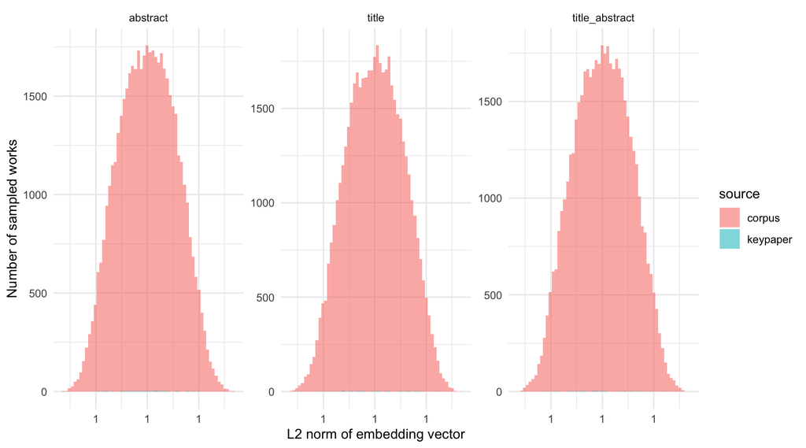

Figure 13: Distribution of L2 norms of embedding vectors per (source × variant), sampled to 50,000 rows per leaf, seed = 13. Expect a tight peak — outliers or wide spread suggest input or model issues.

```r
tar_read(viz_emb_norm_fig)
```

# Provenance

Everything needed to reproduce this report.

```r
cfg <- yaml::read_yaml("input/config.yaml")
active_cfg <- cfg$embeddings$active
emb_cfg <- cfg$embeddings$configs[[active_cfg]]

# Embedding dimension from one parquet file
emb_dim <- {
  one_file <- list.files(
    dirname(tar_read(emb_tcac20_title)),
    pattern = "\\.parquet$",
    full.names = TRUE,
    recursive = TRUE
  )[[1]]
  v_cols <- grep(
    "^V[0-9]+$",
    names(arrow::open_dataset(one_file)),
    value = TRUE
  )
  length(v_cols)
}

git_sha <- tryCatch(
  trimws(system("git rev-parse --short HEAD", intern = TRUE)),
  error = function(e) "unknown"
)

tibble::tibble(
  field = c(
    "active embedding config",
    "model id",
    "embedding dimension",
    "title cap (chars, combined variant)",
    "separator token",
    "TEI host",
    "report rendered",
    "git commit"
  ),
  value = c(
    active_cfg,
    emb_cfg$model %||% "—",
    as.character(emb_dim),
    as.character(emb_cfg$title_cap_combined %||% "—"),
    emb_cfg$sep_token %||% "—",
    paste0(emb_cfg$scheme %||% "http", "://", emb_cfg$host),
    format(Sys.time(), "%Y-%m-%d %H:%M:%S %Z"),
    git_sha
  )
) |>
  knitr::kable(
    caption = "Run provenance — paste into the methods section verbatim."
  )
```

Table 7: Run provenance — paste into the methods section verbatim.

| field | value |
| --- | --- |
| active embedding config | SPECTER2_runpod |
| model id | allenai/specter2_proximity_merged |
| embedding dimension | 768 |
| title cap (chars, combined variant) | 200 |
| separator token | [SEP] |
| TEI host | https://jxg8wguztasqdd-8080.proxy.runpod.net |
| report rendered | 2026-07-02 20:48:02 CEST |
| git commit | 75427ad |